# Quick Project 1

Yahya Gahbiche

May 11, 2020

```r
# Course: 3210 Communicating Data
# Purpose: Quick project 1
# Date: 5/11/2020
# Author: Yahya Gahbiche
```

```r
# Clear environment of variables and functions
rm(list = ls(all = TRUE))
```

# 1 Project Goal

- The goal of this project is to clean and analyze the dataset from the 2014-15 home sales in King County in order to find insights or patterns from the variables we have interest in. We will do base and detailed EDA in R Markdown. The deliverables will be given to Jennifer Lee in the form of a Technical Appendix. A memo will also be prepared and presented to a non-technical person, the hiring manager of Zillow.

# 2 Load Packages

```r
# Load packages

library(tidyverse)
library(patchwork)
library(GGally)
library(readr)
library(lubridate)
library(gridExtra)
library(scales)
library(janitor)
library(knitr)
library(dplyr)
```

# 3 Load and transforming data

```r
# Loading data
home <- read.csv("kc_home_sales.csv")

# Taking a look at our data structures
str(home)
```

```
## 'data.frame':    21613 obs. of  16 variables:
##  $ date        : int  20141013 20141209 20150225 20141209 20150218 20140512 20140627 20150115 20150415 20150312 ...
##  $ price       : num  221900 538000 180000 604000 510000 ...
##  $ bedrooms    : int  3 3 2 4 3 4 3 3 3 3 ...
##  $ bathrooms   : num  1 2.25 1 3 2 4.5 2.25 1.5 1 2.5 ...
##  $ sqft_living : int  1180 2570 770 1960 1680 5420 1715 1060 1780 1890 ...
##  $ sqft_lot    : int  5650 7242 10000 5000 8080 101930 6819 9711 7470 6560 ...
##  $ floors      : num  1 2 1 1 1 1 2 1 1 2 ...
##  $ waterfront  : int  0 0 0 0 0 0 0 0 0 0 ...
##  $ view        : int  0 0 0 0 0 0 0 0 0 0 ...
##  $ grade       : int  7 7 6 7 8 11 7 7 7 7 ...
##  $ condition   : int  3 3 3 5 3 3 3 3 3 3 ...
##  $ yr_built    : int  1955 1951 1933 1965 1987 2001 1995 1963 1960 2003 ...
##  $ yr_renovated: int  0 1991 0 0 0 0 0 0 0 0 ...
##  $ zip_code    : int  98178 98125 98028 98136 98074 98053 98003 98198 98146 98038 ...
##  $ lat         : num  47.5 47.7 47.7 47.5 47.6 ...
##  $ long        : num  -122 -122 -122 -122 -122 ...
```

```r
# Transforming data: Converting variables into factors

home$bedrooms <- as.factor(home$bedrooms)
home$bathrooms <- as.factor(home$bathrooms)
home$floors <- as.factor(home$floors)
home$waterfront <- as.factor(home$waterfront)
home$view <- as.factor(home$view)
home$grade <- as.factor(home$grade)
home$condition <- as.factor(home$condition)

# converting the variable date into date format
home$date <- ymd(home$date)

# Correcting incorrect data in bedroom
home$bedrooms[home$bedrooms == 33] <- 3

# Removing variables we don't need
home <- select(home,-c(zip_code, lat, long))
```

# 4 Base EDA Step 1: Uni-variate non-graphical EDA

```r
# View the data
head(home)
```

```
##         date   price bedrooms bathrooms sqft_living sqft_lot floors
## 1 2014-10-13  221900        3         1        1180     5650      1
## 2 2014-12-09  538000        3      2.25        2570     7242      2
## 3 2015-02-25  180000        2         1         770    10000      1
## 4 2014-12-09  604000        4         3        1960     5000      1
## 5 2015-02-18  510000        3         2        1680     8080      1
## 6 2014-05-12 1230000        4       4.5        5420   101930      1
##   waterfront view grade condition yr_built yr_renovated
## 1          0    0     7         3     1955            0
## 2          0    0     7         3     1951         1991
## 3          0    0     6         3     1933            0
## 4          0    0     7         5     1965            0
## 5          0    0     8         3     1987            0
## 6          0    0    11         3     2001            0
```

**Comments**

- We can see all the variables of the dataset that we need, along with the changes that we made like the format of the date. The variables we removed are not necessary so we won’t need them in the analysis.

**Check the structure of the data**

```r
str(home)
```

```
## 'data.frame':    21613 obs. of  13 variables:
##  $ date        : Date, format: "2014-10-13" "2014-12-09" ...
##  $ price       : num  221900 538000 180000 604000 510000 ...
##  $ bedrooms    : Factor w/ 13 levels "0","1","2","3",..: 4 4 3 5 4 5 4 4 4 4 ...
##  $ bathrooms   : Factor w/ 30 levels "0","0.5","0.75",..: 4 9 4 12 8 18 9 6 4 10 ...
##  $ sqft_living : int  1180 2570 770 1960 1680 5420 1715 1060 1780 1890 ...
##  $ sqft_lot    : int  5650 7242 10000 5000 8080 101930 6819 9711 7470 6560 ...
##  $ floors      : Factor w/ 6 levels "1","1.5","2",..: 1 3 1 1 1 1 3 1 1 3 ...
##  $ waterfront  : Factor w/ 2 levels "0","1": 1 1 1 1 1 1 1 1 1 1 ...
##  $ view        : Factor w/ 5 levels "0","1","2","3",..: 1 1 1 1 1 1 1 1 1 1 ...
##  $ grade       : Factor w/ 12 levels "1","3","4","5",..: 6 6 5 6 7 10 6 6 6 6 ...
##  $ condition   : Factor w/ 5 levels "1","2","3","4",..: 3 3 3 5 3 3 3 3 3 3 ...
##  $ yr_built    : int  1955 1951 1933 1965 1987 2001 1995 1963 1960 2003 ...
##  $ yr_renovated: int  0 1991 0 0 0 0 0 0 0 0 ...
```

**Summary table of the variables**

```r
summary(home)
```

```
##       date                price            bedrooms      bathrooms
##  Min.   :2014-05-02   Min.   :  75000   3      :9825   2.5    :5380
##  1st Qu.:2014-07-22   1st Qu.: 321950   4      :6882   1      :3852
##  Median :2014-10-16   Median : 450000   2      :2760   1.75   :3048
##  Mean   :2014-10-29   Mean   : 540182   5      :1601   2.25   :2047
##  3rd Qu.:2015-02-17   3rd Qu.: 645000   6      : 272   2      :1930
##  Max.   :2015-05-27   Max.   :7700000   1      : 199   1.5    :1446
##                                         (Other):  74   (Other):3910
##   sqft_living       sqft_lot       floors      waterfront view
##  Min.   :  290   Min.   :    520   1  :10680   0:21450    0:19489
##  1st Qu.: 1427   1st Qu.:   5040   1.5: 1910   1:  163    1:  332
##  Median : 1910   Median :   7618   2  : 8241              2:  963
##  Mean   : 2080   Mean   :  15107   2.5:  161              3:  510
##  3rd Qu.: 2550   3rd Qu.:  10688   3  :  613              4:  319
##  Max.   :13540   Max.   :1651359   3.5:    8
##
##      grade      condition    yr_built     yr_renovated
##  7      :8981   1:   30   Min.   :1900   Min.   :   0.0
##  8      :6068   2:  172   1st Qu.:1951   1st Qu.:   0.0
##  9      :2615   3:14031   Median :1975   Median :   0.0
##  6      :2038   4: 5679   Mean   :1971   Mean   :  84.4
##  10     :1134   5: 1701   3rd Qu.:1997   3rd Qu.:   0.0
##  11     : 399             Max.   :2015   Max.   :2015.0
##  (Other): 378
```

**Comments**

**Questions**

- How many houses are sold over time?
- How many houses are sold at different prices?
- How does the number of bedrooms affect the prices of homes?
- As the number of floor increases does the square footage increase as well?
- What’s the relationship between square footage and price?
- How is the year built variable affecting the price?
- Does a home with a higher number of floors mean they have a better view?
- Do homes with waterfront always have a good view?

# 5 Base EDA Step 2: Uni-Variate graphical EDA

## 5.1 Step 2.1: Categorical/ Factor variables:

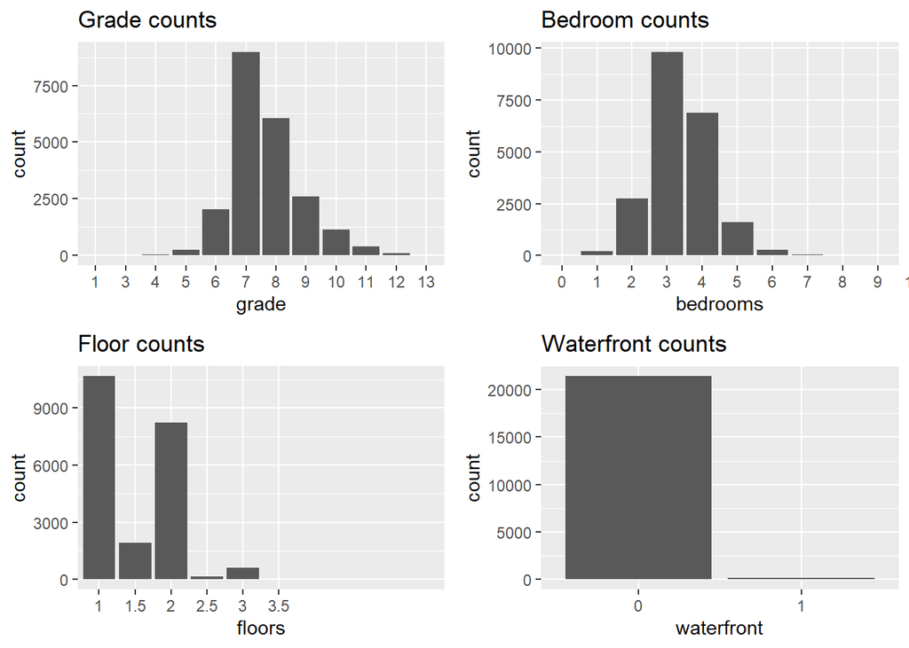

```r
grid.arrange(

home %>%
  ggplot(mapping = aes(x = grade)) +
  geom_bar()+
  ggtitle("Grade counts"),

home %>%
  ggplot(mapping = aes(x = bedrooms)) +
  geom_bar()+
  ggtitle("Bedroom counts")+
  coord_cartesian(xlim =c(1,10)),

home %>%
  ggplot(mapping = aes(x = floors)) +
  geom_bar()+
  ggtitle("Floor counts")+
  coord_cartesian(xlim =c(1,10)),

home %>%
  ggplot(mapping = aes(x = waterfront)) +
  geom_bar()+
  ggtitle("Waterfront counts"),



ncol = 2
)
```

**Bathrooms visualization**

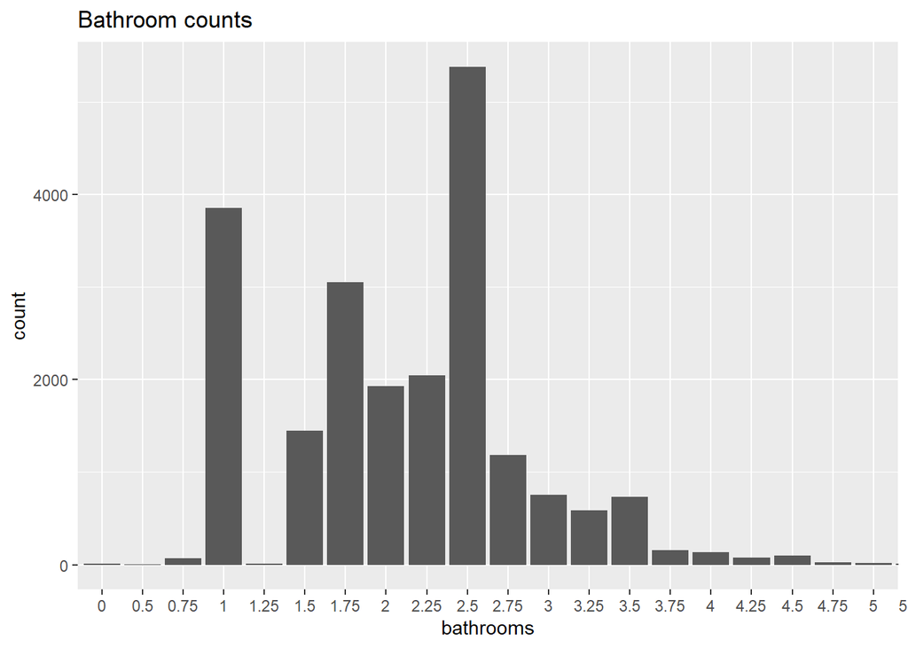

```r
home %>%
  ggplot(mapping = aes(x = bathrooms)) +
  geom_bar()+
  ggtitle("Bathroom counts")+
  coord_cartesian(xlim =c(1,20))
```

**View visualization**

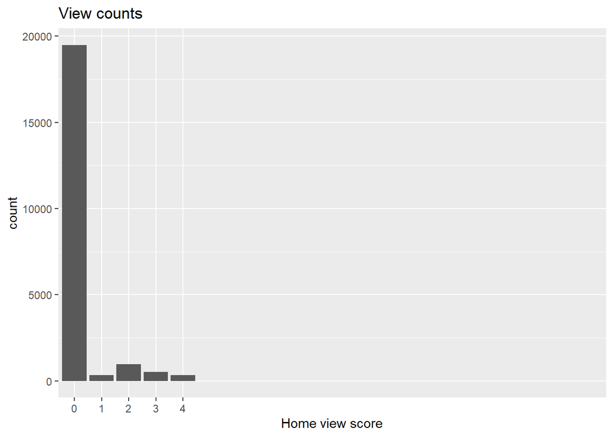

```r
home %>%
  ggplot(mapping = aes(x = view)) +
  geom_bar()+ xlab ("Home view score") +
  ggtitle("View counts")+
  coord_cartesian(xlim =c(1,20))
```

**Date**

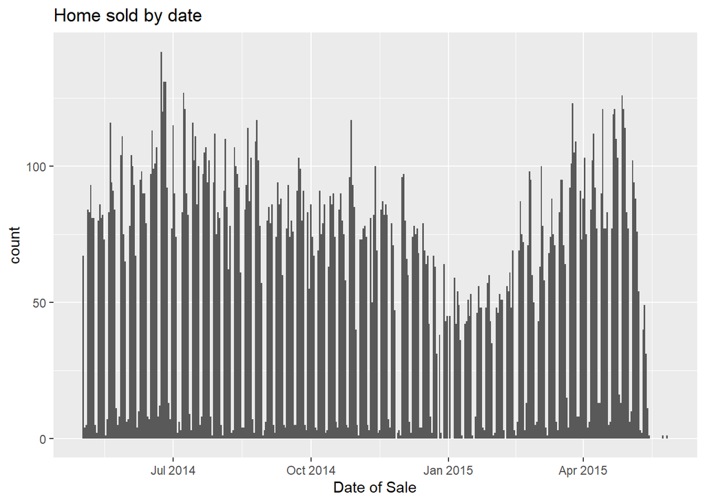

```r
home %>%
  ggplot(mapping = aes(x = date)) +
  geom_bar(binwidth = 1)+ xlab("Date of Sale") +
  ggtitle("Home sold by date")
```

**Comments**

- *Grade*: Most homes have a score of 7 and 8 while very few have a score of less than 6 or more than 10. Most homes are average homes.
- *Bedrooms*: The majority of homes have 3 bedrooms with a count of 9825 while few have either 5+ or 1 bedroom. Having 1 bedroom can be a studio or a small apartment.
- *Floors*: The most common number of floor in a home is 1 floor with a count of 10680. A significant number of homes also have 2 floors, the count is 8241. There aren’t many home with more than 2 floors. My guess is even large homes would rather have more square footage than multiple floors.
- *Waterfront*: 21450 of the homes in the data don’t have a waterfront and only 163 have a view on the waterfront. We might want to look at the correlation between waterfront view. Most homes don’t have a good view.
- *Date*: The number of homes sold peak at around July 2014 and the falls in January and February. The home sales count increases again in April and May.
- This tells us that the housing market relies heavily on seasons. Summer seems to be the busiest season to buy a home wherease in winter not many people purchase homes.

**Questions**

- Is there a correlation between the number of bedrooms and the price of the lot?
- How does the square footage increase with the increase of the number of floors?

## 5.2 Step 2.2: Quantitative

**Price**

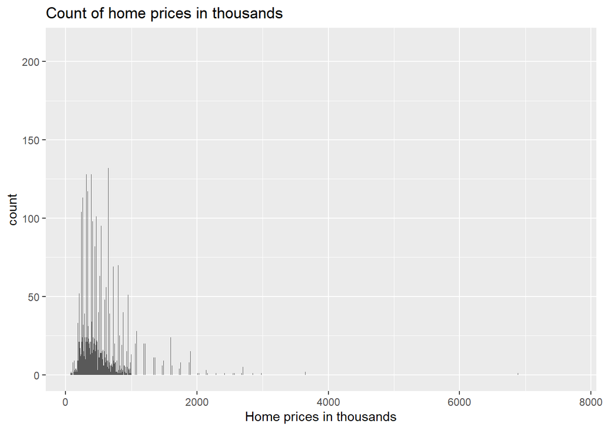

```r
home %>%
  ggplot(mapping = aes(x = price/1000)) +
  geom_histogram(binwidth = 1) + xlab("Home prices in thousands")+
  ggtitle("Count of home prices in thousands")
```

**Comments**

- We can see the shape of the graph but it’s hard to read the values. We might want to ignore outliers with high prices for now and focus on the dense part of the curve. We’ll take homes with 3 million dollars and less.

```r
# Creating a subset of prices less than 3 million dollars.

home_subset <- subset(home, home$price< 3000000)
```

- Recreating the visualization of price in thousands using home prices less than $3 million. We will also have the square footage variable next to the price variable for pattern detection. We’ll use grid.arrange

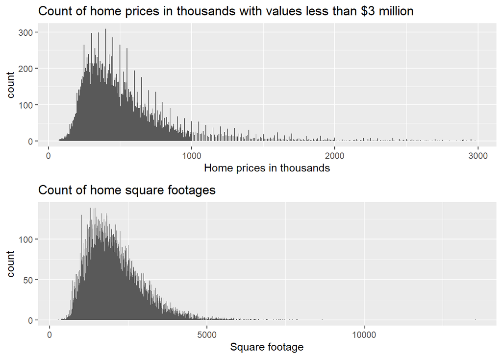

```r
graph_1 <- grid.arrange(

# price graph
home_subset %>%
  ggplot(mapping = aes(x = price/1000)) +
  geom_histogram(binwidth = 5) + xlab("Home prices in thousands")+
  ggtitle("Count of home prices in thousands with values less than $3 million"),

# sqft_living graph
home_subset %>%
  ggplot(mapping = aes(x = sqft_living)) +
  geom_histogram(binwidth = 10) + xlab("Square footage")+
  ggtitle("Count of home square footages "),

ncol = 1
)
```

```r
graph_1
```

**Comments**

- One thing we notice is that the majority of homes are worth less than 1 million dollar.
- We have a high concentration of homes sold at less than $500,000.
- Average home square footage is 2080, most homes have less than 5000 sqft in space.
- It is very evident that price and square footage are positively correlated.

**Question**

- How is the price and square footage correlated?

# 6 Base EDA Step 3: Multi-variate non-graphical

## 6.1 Step 3.1: Categorical

**Bathrooms and bedrooms**

```r
# Countingency/cross table

home_subset %>%
  tabyl(bathrooms, bedrooms) %>%
  adorn_totals(where = c("row","col")) %>%
  adorn_title(placement = "combined", "Number of bathrooms", "Number of bedrooms") %>%
  kable()
```

| Number of bathrooms/Number of bedrooms | 0 | 1 | 2 | 3 | 4 | 5 | 6 | 7 | 8 | 9 | 10 | 11 | 33 | Total |
| --- | --- | --- | --- | --- | --- | --- | --- | --- | --- | --- | --- | --- | --- | --- |
| 0 | 7 | 3 | 0 | 0 | 0 | 0 | 0 | 0 | 0 | 0 | 0 | 0 | 0 | 10 |
| 0.5 | 0 | 1 | 2 | 0 | 1 | 0 | 0 | 0 | 0 | 0 | 0 | 0 | 0 | 4 |
| 0.75 | 1 | 27 | 26 | 16 | 2 | 0 | 0 | 0 | 0 | 0 | 0 | 0 | 0 | 72 |
| 1 | 1 | 138 | 1558 | 1780 | 325 | 43 | 6 | 1 | 0 | 0 | 0 | 0 | 0 | 3852 |
| 1.25 | 0 | 2 | 3 | 4 | 0 | 0 | 0 | 0 | 0 | 0 | 0 | 0 | 0 | 9 |
| 1.5 | 1 | 12 | 294 | 829 | 254 | 48 | 6 | 2 | 0 | 0 | 0 | 0 | 0 | 1446 |
| 1.75 | 0 | 4 | 303 | 1871 | 719 | 134 | 16 | 0 | 0 | 0 | 0 | 0 | 0 | 3047 |
| 2 | 0 | 6 | 216 | 1048 | 525 | 110 | 24 | 0 | 0 | 0 | 1 | 0 | 0 | 1930 |
| 2.25 | 0 | 4 | 118 | 1082 | 709 | 116 | 15 | 3 | 0 | 0 | 0 | 0 | 0 | 2047 |
| 2.5 | 3 | 2 | 197 | 2356 | 2502 | 287 | 29 | 2 | 1 | 0 | 0 | 0 | 0 | 5379 |
| 2.75 | 0 | 0 | 20 | 275 | 639 | 214 | 31 | 3 | 3 | 0 | 0 | 0 | 0 | 1185 |
| 3 | 0 | 0 | 13 | 196 | 325 | 162 | 45 | 3 | 2 | 2 | 1 | 1 | 0 | 750 |
| 3.25 | 0 | 0 | 8 | 181 | 252 | 128 | 12 | 1 | 1 | 0 | 0 | 0 | 0 | 583 |
| 3.5 | 0 | 0 | 1 | 141 | 393 | 168 | 17 | 5 | 1 | 0 | 0 | 0 | 0 | 726 |
| 3.75 | 0 | 0 | 0 | 17 | 77 | 41 | 13 | 2 | 1 | 0 | 0 | 0 | 0 | 151 |
| 4 | 0 | 0 | 0 | 11 | 56 | 47 | 11 | 5 | 1 | 1 | 0 | 0 | 0 | 132 |
| 4.25 | 0 | 0 | 0 | 5 | 36 | 25 | 7 | 2 | 0 | 0 | 0 | 0 | 0 | 75 |
| 4.5 | 0 | 0 | 0 | 4 | 32 | 33 | 23 | 2 | 0 | 2 | 0 | 0 | 0 | 96 |
| 4.75 | 0 | 0 | 0 | 0 | 7 | 10 | 2 | 2 | 0 | 0 | 0 | 0 | 0 | 21 |
| 5 | 0 | 0 | 0 | 0 | 6 | 5 | 5 | 0 | 1 | 0 | 0 | 0 | 0 | 17 |
| 5.25 | 0 | 0 | 0 | 0 | 5 | 2 | 3 | 0 | 0 | 0 | 1 | 0 | 0 | 11 |
| 5.5 | 0 | 0 | 0 | 0 | 4 | 2 | 0 | 1 | 0 | 0 | 0 | 0 | 0 | 7 |
| 5.75 | 0 | 0 | 0 | 0 | 1 | 1 | 0 | 1 | 0 | 0 | 0 | 0 | 0 | 3 |
| 6 | 0 | 0 | 0 | 0 | 0 | 2 | 0 | 0 | 1 | 0 | 0 | 0 | 0 | 3 |
| 6.25 | 0 | 0 | 0 | 0 | 0 | 1 | 0 | 0 | 0 | 0 | 0 | 0 | 0 | 1 |
| 6.5 | 0 | 0 | 0 | 0 | 0 | 1 | 1 | 0 | 0 | 0 | 0 | 0 | 0 | 2 |
| 6.75 | 0 | 0 | 0 | 0 | 0 | 0 | 0 | 1 | 0 | 0 | 0 | 0 | 0 | 1 |
| 7.5 | 0 | 0 | 0 | 0 | 0 | 0 | 0 | 0 | 0 | 1 | 0 | 0 | 0 | 1 |
| 7.75 | 0 | 0 | 0 | 0 | 0 | 0 | 0 | 0 | 0 | 0 | 0 | 0 | 0 | 0 |
| 8 | 0 | 0 | 0 | 0 | 0 | 0 | 0 | 1 | 0 | 0 | 0 | 0 | 0 | 1 |
| Total | 13 | 199 | 2759 | 9816 | 6870 | 1580 | 266 | 37 | 12 | 6 | 3 | 1 | 0 | 21562 |

**Comments**

```r
# Countingency/cross table

home_subset %>%
  tabyl(bedrooms, floors) %>%
  adorn_totals(where = c("row","col")) %>%
  adorn_title( placement = "combined", "Number of bedrooms", "Number of floors") %>%
  kable()
```

| Number of bedrooms/Number of floors | 1 | 1.5 | 2 | 2.5 | 3 | 3.5 | Total |
| --- | --- | --- | --- | --- | --- | --- | --- |
| 0 | 4 | 0 | 6 | 0 | 2 | 1 | 13 |
| 1 | 162 | 21 | 12 | 1 | 3 | 0 | 199 |
| 2 | 1951 | 182 | 497 | 4 | 123 | 2 | 2759 |
| 3 | 5453 | 786 | 3112 | 56 | 405 | 4 | 9816 |
| 4 | 2379 | 698 | 3674 | 58 | 61 | 0 | 6870 |
| 5 | 601 | 185 | 759 | 22 | 13 | 0 | 1580 |
| 6 | 104 | 29 | 117 | 12 | 4 | 0 | 266 |
| 7 | 9 | 7 | 19 | 1 | 1 | 0 | 37 |
| 8 | 5 | 1 | 6 | 0 | 0 | 0 | 12 |
| 9 | 0 | 0 | 4 | 2 | 0 | 0 | 6 |
| 10 | 1 | 0 | 2 | 0 | 0 | 0 | 3 |
| 11 | 0 | 0 | 1 | 0 | 0 | 0 | 1 |
| 33 | 0 | 0 | 0 | 0 | 0 | 0 | 0 |
| Total | 10669 | 1909 | 8209 | 156 | 612 | 7 | 21562 |

**Comments**

- Comparing the number of floors with the number of bedrooms we find that most homes have:
  - 1 floor, 2 bedrooms
  - 1 floor, 3 bedrooms
  - 1 floor, 4 bedrooms
  - 2 floors, 3 bedrooms
  - 2 floors, 4 bedrooms

**View and Floors**

```r
# Countingency/cross table

home %>%
  tabyl(floors, view) %>%
  adorn_totals(where = c("row","col")) %>%
  adorn_title(placement = "combined", "Number of floors", "Home view score") %>%
  kable()
```

| Number of floors/Home view score | 0 | 1 | 2 | 3 | 4 | Total |
| --- | --- | --- | --- | --- | --- | --- |
| 1 | 9684 | 192 | 454 | 219 | 131 | 10680 |
| 1.5 | 1713 | 27 | 90 | 50 | 30 | 1910 |
| 2 | 7407 | 108 | 376 | 215 | 135 | 8241 |
| 2.5 | 130 | 0 | 17 | 8 | 6 | 161 |
| 3 | 549 | 5 | 24 | 18 | 17 | 613 |
| 3.5 | 6 | 0 | 2 | 0 | 0 | 8 |
| Total | 19489 | 332 | 963 | 510 | 319 | 21613 |

**Comments**

- It is evident that the majority of homes with 1 floor don’t have a good view.
- Homes with 2 floors also don’t have a nice view
- Homes with 3 floors have better views but still not excellent views
- A logical interpretation of this is that these homes are located in a metropolitan area where there are high-rise buildings around. 2 or 3 floor won’t make a significant change in the homes views.

**Waterfront and view**

```r
home %>%
  tabyl(waterfront, view) %>%
  adorn_totals(where = c("row","col")) %>%
  adorn_title(placement = "combined", "Waterfront", "Home view score") %>%
  kable()
```

| Waterfront/Home view score | 0 | 1 | 2 | 3 | 4 | Total |
| --- | --- | --- | --- | --- | --- | --- |
| 0 | 19489 | 331 | 955 | 491 | 184 | 21450 |
| 1 | 0 | 1 | 8 | 19 | 135 | 163 |
| Total | 19489 | 332 | 963 | 510 | 319 | 21613 |

**Comments**

- In the group of homes with a waterfront view, 135 homes have a view score of 4, whereas only 1 house has a score of 1, and 0 homes have a score of 0.
- This tables shows that the if a home is on a waterfront it must have a better view. We now have just answered one of our questions.

## 6.2 Step 3.2: Quantitative

```r
# Correlation table

home %>%
  select_if(is.numeric) %>%
  cor() %>%
  round(2) %>%
  kable()
```

|  | price | sqft_living | sqft_lot | yr_built | yr_renovated |
| --- | --- | --- | --- | --- | --- |
| price | 1.00 | 0.70 | 0.09 | 0.05 | 0.13 |
| sqft_living | 0.70 | 1.00 | 0.17 | 0.32 | 0.06 |
| sqft_lot | 0.09 | 0.17 | 1.00 | 0.05 | 0.01 |
| yr_built | 0.05 | 0.32 | 0.05 | 1.00 | -0.22 |
| yr_renovated | 0.13 | 0.06 | 0.01 | -0.22 | 1.00 |

**Comments**

- This table shows that living sqft and price are positively correlated with a value of 0.7 which is considered high.

**Questions**

- How does the price interact with the square footage graphically?

# 7 Base EDA Step 4: Multi-variate graphical

## 7.1 Step 4.1: Categorical:

**Looking at multiple variables at a time**

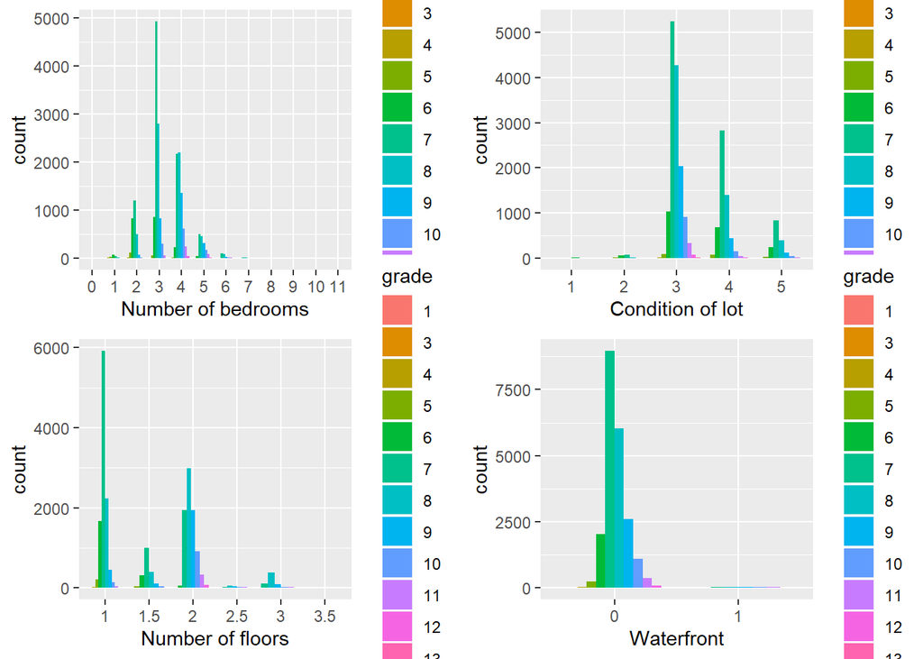

```r
grid.arrange(

  # bedrooms
  home %>%
    ggplot(mapping = aes(x = bedrooms, fill = grade)) +
    geom_bar(position = "dodge") + xlab("Number of bedrooms"),

  #Condition
  home %>%
    ggplot(mapping = aes(x = condition, fill = grade)) +
    geom_bar(position = "dodge") + xlab("Condition of lot"),

  #floors
  home %>%
    ggplot(mapping = aes(x = floors, fill = grade)) +
    geom_bar(position = "dodge") + xlab("Number of floors"),

  # waterfront
  home %>%
    ggplot(mapping = aes(x = waterfront, fill = grade)) +
    geom_bar(position = "dodge") + xlab("Waterfront"),

  ncol = 2
)
```

**Graphing the variables bathrooms and grade separately as it’s easier to read this way**

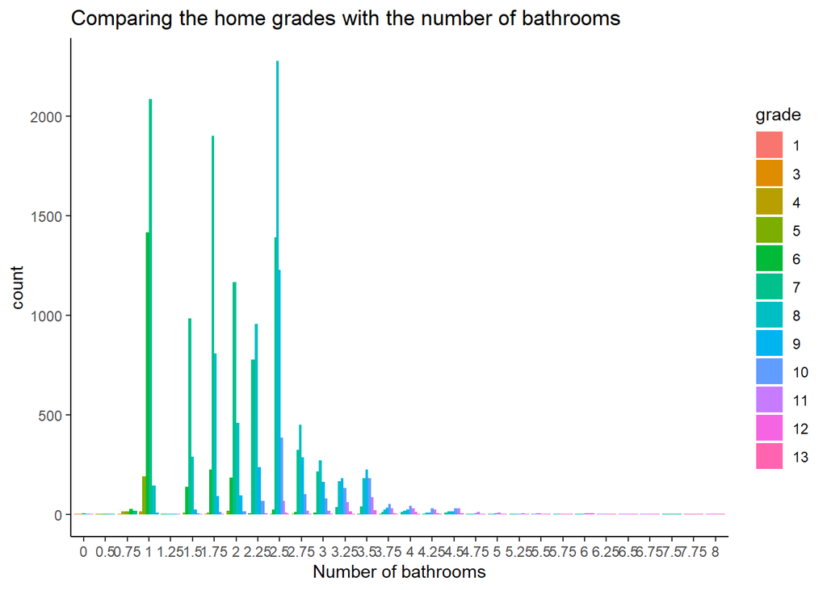

```r
# bathroom
home %>%
    ggplot(mapping = aes(x = bathrooms, fill = grade)) +
    geom_bar(position = "dodge") + xlab("Number of bathrooms") +
    ggtitle("Comparing the home grades with the number of bathrooms") +
    theme_classic()
```

**Comments**

## 7.2 Step 4.2: Quantitative

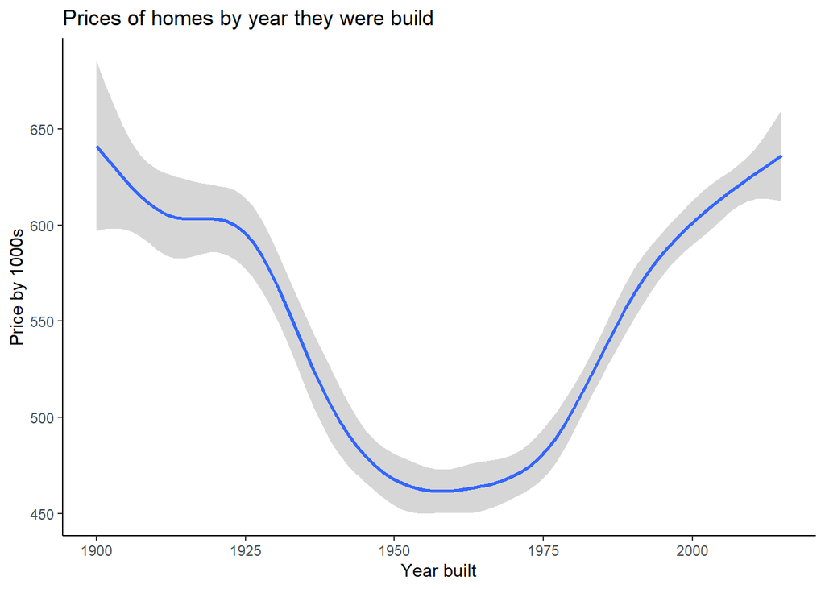

```r
graph_2 <- home %>%
  ggplot(mapping = aes(x = yr_built, y = price/1000)) +
  geom_smooth() + xlab("Year built") + ylab("Price by 1000s") +
  ggtitle("Prices of homes by year they were build") +
  theme_classic()
graph_2
```

**Comments**

- We can divide this smooth line graph into 3 segments:
  - The first segment is from 1900 to 1925: Prices are high: This can be explained by authenticity because for these homes have historical values. Much like wine, the older it is the more expensive it gets.
  - The second segment is from 1925 to 1975: Prices are low and they remain at that level for a while. Homes don’t hold a high value because neither very authentic nor very modern.
  - The fird and last segment starts from homes built in 1975 start to gain a higher value until the present day. Homes became more modern, the luxurous lifestyle became a trend, new engeneering techniques and strong building materials have been introduced. Those factors increase the value of homes.

## 7.3 Step 4.3: Categorical and Quantitative

**Looking at how prices vary with number of bedrooms and square footage**

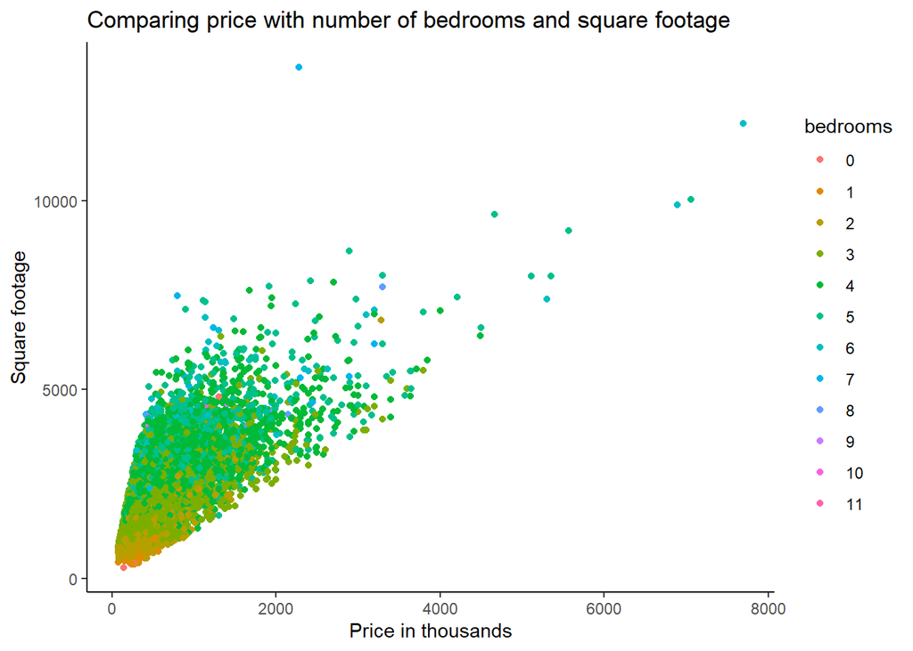

```r
# Detailed Scatter plot

home %>%
    ggplot(mapping = aes(x = price/1000, y = sqft_living, color = bedrooms))+
    geom_point() + xlab("Price in thousands") + ylab("Square footage") +
    theme_classic() +
    ggtitle("Comparing price with number of bedrooms and square footage")
```

**Comments**

- As the square footage increase so does the price of the homes. Most homes look green indicating that most homes have 3 to 6 bedrooms.
- We can see some blue data points increasing as the square footage increase. This indicates that the number of bedrooms increase the value of properties.

**Looking at how the number of floors affect the square footage of living**

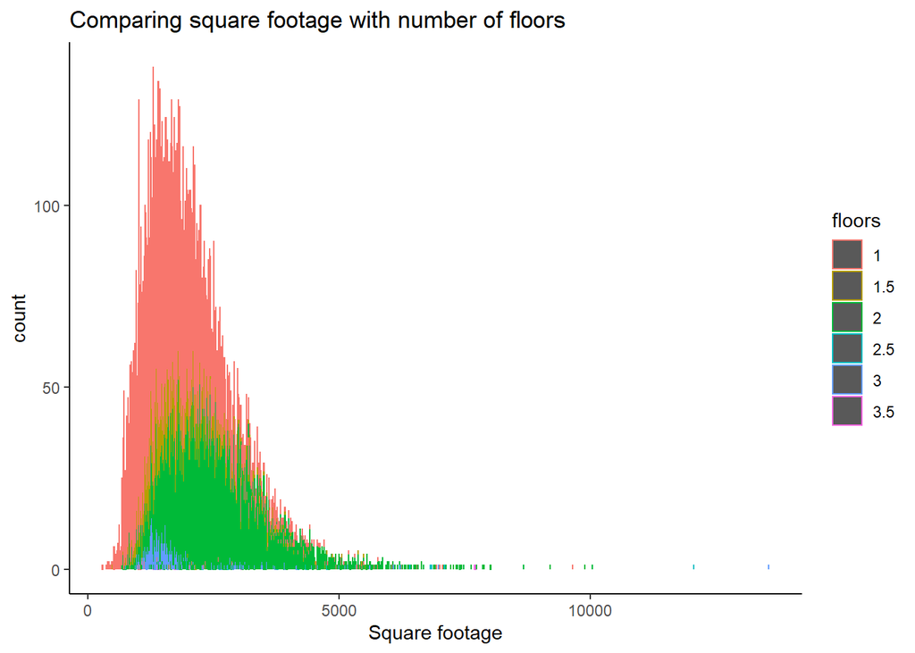

```r
graph_3 <-

 home %>%
    ggplot(mapping = aes(x = sqft_living, color = floors))+
    geom_bar() + xlab("Square footage") +
    theme_classic() +
    ggtitle("Comparing square footage with number of floors")

graph_3
```

**Comments**

# 8 Detailed EDA - Questions raised in Base EDA

## 8.1 Question 1: How are the prices changing for homes built after the year 2005 with only 1 floor?

**Creating a subset for homes built after 2005 with only 1 floor**

```r
#Subset: 1 Floor, yr_built after 2005

subset_1 <- home %>%
  select(c("price", "date", "floors", "sqft_lot", "yr_built")) %>%
  filter(floors == "1",  yr_built > 2005)
```

**Summary of the new subset**

```r
summary(subset_1)
```

```
##      price              date            floors       sqft_lot
##  Min.   : 155000   Min.   :2014-05-02   1  :150   Min.   :  1060
##  1st Qu.: 389000   1st Qu.:2014-07-09   1.5:  0   1st Qu.:  4950
##  Median : 500000   Median :2014-09-23   2  :  0   Median :  7032
##  Mean   : 596425   Mean   :2014-10-19   2.5:  0   Mean   : 23096
##  3rd Qu.: 699912   3rd Qu.:2015-02-11   3  :  0   3rd Qu.: 10357
##  Max.   :3350000   Max.   :2015-05-11   3.5:  0   Max.   :276170
##     yr_built
##  Min.   :2006
##  1st Qu.:2007
##  Median :2008
##  Mean   :2009
##  3rd Qu.:2010
##  Max.   :2014
```

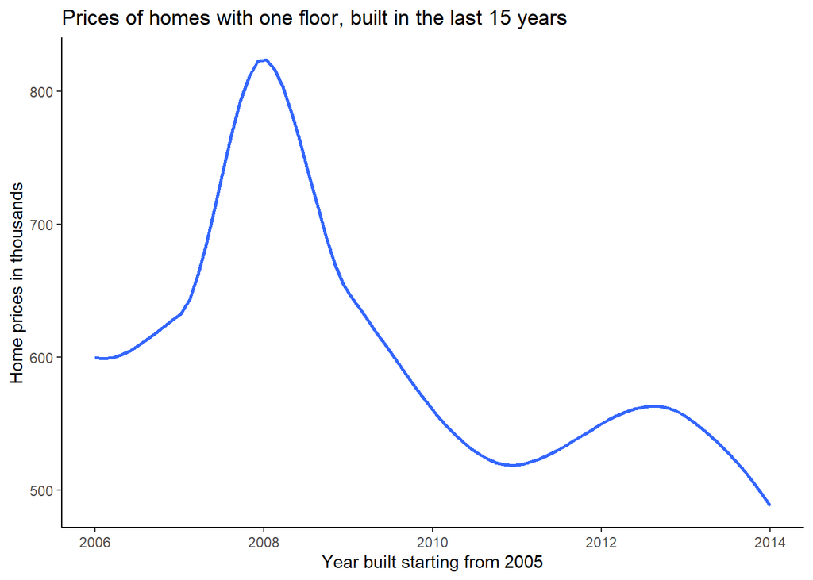

```r
# graphing prices that have only 1 floor

homes_in_recession <- subset_1 %>%
  ggplot(mapping = aes(x = yr_built, y = price/1000)) +
  geom_smooth(se = FALSE) + xlab("Year built starting from 2005") +
  ylab("Home prices in thousands") +
  ggtitle("Prices of homes with one floor, built in the last 15 years") +
  theme_classic()
homes_in_recession
```

**Comments**

- We filtered the homes with 1 floor as it is the most common number of floor available for homes in the US.
- We also filtered the years starting from the year 2005.
- Prices started to increase from 2005 until 2008. This was due to the **housing bubble** where people and real estate companies started building homes and banks giving home loans. This had resulted in a tremendous peak in the prices of homes.
- The drop in prices after 2008 represents the **burst of housing bubble**, this was a major factor in causing the **great recession of 2007-2009**. Prices only started to recover from 2011 and they are still unstable until today.

## 8.2 Question 2: How does the square footage and view affect home prices?

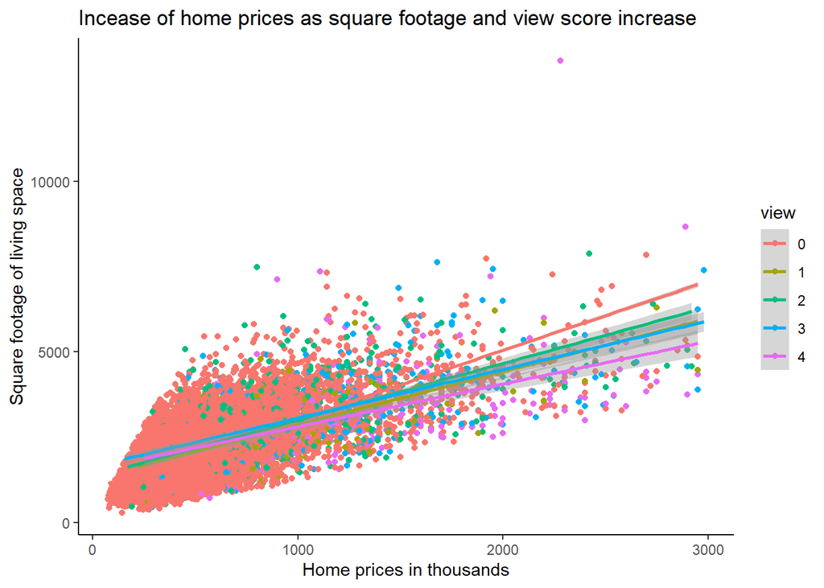

```r
graph_4 <-

home_subset %>%
  ggplot(mapping = aes(x = price/1000 , y = sqft_living , color = view)) +
  geom_point() + xlab("Home prices in thousands") +
  ylab("Square footage of living space")+
  geom_smooth(method = 'lm') +
  ggtitle("Incease of home prices as square footage and view score increase") +
  theme_classic()
graph_4
```

**CommentS**

# 9 Summary

```r
ggsave(filename = 'Comparing lot prices with square footage.png', plot = graph_1)
ggsave(filename = 'Price of lots by year built.png', plot = graph_2)
ggsave(filename = 'Comparing square footage with number of floors.png', plot = graph_3)
ggsave(filename = 'Incease of home prices as square footage and view score increase.png', plot = graph_4)
ggsave(filename = 'Home prices with one floor during the great recession.png', plot = homes_in_recession)
```